# **Evalutating the Performance of Hybrid LSTM-ARIMA Model to Forecast NDXT-100**

**PHYS664 Final Report | May 23rd, 2025**

Yuca Chen: github.com/yucachen, yucachen@udel.edu, Communication and Analysis Manager

Jacklyn Clauss: github.com/jclauss24, jclauss@udel.edu, Data Manager

Skyler Lindsey: github.com/skyler-ud, skyel@udel.edu, Literature and Analysis Manager

Dayanara Yanez: github.com/dayaYanez, dayalyz@udel.edu, Visualization Manager

> Abstract

> Introduction

> Data

> Methodology

> > Finding the Residuals of the Datasets from an ARIMA Fit Using AIC Criterion

> > Using ARIMA to Generate Predictions of NDXT-100 behavior

> > Using LSTM to model the residual behavior

> Results

> > Model Loss Behavior

> > LSTM + ARIMA and ARIMA-only Prediction and Forecast

> Conclusions and Future Work

> Link to GitHub Repo

> Bibliography

# **Abstract**

Recent approaches to modeling stock price behavior over time have utilized machine learning techniques for increased forecasting accuracy, in comparison to traditional models. We forecast the NASDAQ-100 technology sector index, along with using Apple and Google historic stock data and Consumer Price Index data. Prior studies have shown success with using a Long-Short Term Memory (LSTM) recurrent neural network. To try to improve upon this model and to account for seasonality, we integrate an Auto Regressive Integrative Moving Average (ARIMA) model. We will evaluate the performance of this hybrid LSTM-ARIMA model compared to an ARIMA-only model.

# **Introduction**

The average person’s interest in the stock market has grown immensely over the last few decades [1]. Many people, outside of Wall Street, are now trying their hand in investing in the stock market in an attempt to take advantage of this avenue of making money – and who doesn’t want to make money? If the behavior of the market can be forecasted accurately, then a more consistent profit can be made. Additionally, the technology sector is poised for growth for the rest of this decade, which makes it a prime target for stock price forecasting [2]. Stock prices in themselves are also notoriously volatile and difficult to predict - if markets are truly efficient and prices instantly reflect all public information, then a blindfolded monkey throwing darts at stock listings would probably perform as well as a professional investor. This desire for more accurate forecasting for stock price behavior motivates the use of machine learning in order to do these predictions [3].

Among the numerous methods that have been used for stock price forecasting, prominent algorithms that have been widely used in recent studies include artificial neural networks (ANN), support vector machines (SVM), and long short term memory recurrent neural networks (LSTM RNN) [4,5]. A range of different datasets have also been called upon to feed into these algorithms, including time-series data of available stock price information and macroeconomic information [3].

# **Data**

The main data sets used in this project are stock data for the **NDXT-100, Apple, and Google** . The NDXT-100 is the abbreviation for the NASDAQ-100 technology sector, and is a stock index made up of several technological companies. Data on the Consumer Price Index (CPI) is also used.

The NDXT-100 data contains the date, index value, net change in price, and high and low prices. The Apple and Google stock datasets include the date, open price, close/last price, volume traded, high price, and low price. Both of these stock datasets are available daily on those days when the New York Stock Exchange are open. The CPI data is available monthly.

The CPI data was initially organized with the year as the row and the month as the column. This caused there to be an additional step of data processing required to reformat the data into a form that could be worked with more easily.

```python
# @title

# import the necessary packages
import pandas as pd
import numpy as np


# read in each of the seperate data sets
NASDAQ_tech_index = pd.read_csv("https://raw.githubusercontent.com/jclauss24/MTLSA_Project/refs/heads/main/Data/EODHist_20060222-20250315_NDXT.csv")
AAPL_info = pd.read_csv("https://raw.githubusercontent.com/jclauss24/MTLSA_Project/refs/heads/main/Data/HistoricalData_AAPL.csv")
GOOGL_info = pd.read_csv("https://raw.githubusercontent.com/jclauss24/MTLSA_Project/refs/heads/main/Data/HistoricalData_GOOGL.csv")
inflation_info = pd.read_csv("https://raw.githubusercontent.com/jclauss24/MTLSA_Project/refs/heads/main/Data/US_CPI_all_item_city_average%20copy.csv")

# drop two unnecessary columns in the CPI data
inflation_info = inflation_info.drop(columns=['HALF1'])
inflation_info = inflation_info.drop(columns=['HALF2'])

# Melt the CPI DataFrame to reshape it
df_melted = inflation_info.melt(id_vars='Year', var_name='month', value_name='value')

# Combine year and month into a datetime column
df_melted['date'] = pd.to_datetime(df_melted['Year'].astype(str) + '-' + df_melted['month'], format='%Y-%b')

#rename the columns of the newly reshaped CPI dataframe
new_df = df_melted[['date', 'value']].copy()
new_df.columns = ['Date', 'CPI']
new_df = new_df.set_index('Date')

# display the first few rows of the newly reshaped dataframe
new_df.head()
```

| Date | CPI |
| --- | --- |
| 1990-01-01 | 127.4 |
| 1991-01-01 | 134.6 |
| 1992-01-01 | 138.1 |
| 1993-01-01 | 142.6 |
| 1994-01-01 | 146.2 |

Once all of the data was in this same format it was merged together based on the date. The CPI data was then imputed linearly as it was only available once each month.

```python
# @title
NASDAQ_tech_index.columns = ['Date', 'IndexValue_NDXT', 'NetChange_NDXT', 'High_NDXT', 'Low_NDXT']
NASDAQ_tech_index = NASDAQ_tech_index.set_index('Date')
NASDAQ_tech_index.index = pd.to_datetime(NASDAQ_tech_index.index) # datatype that counts nanoseconds, relatively complex datatype in pandas ("one of best to use")

# prompt: remove comma in column "IndexValue_NDXT"
NASDAQ_tech_index["IndexValue_NDXT"] = NASDAQ_tech_index["IndexValue_NDXT"].astype(str).str.replace(",","").astype(float)
NASDAQ_tech_index["High_NDXT"] = NASDAQ_tech_index["High_NDXT"].astype(str).str.replace(",","").astype(float)
NASDAQ_tech_index["Low_NDXT"] = NASDAQ_tech_index["Low_NDXT"].astype(str).str.replace(",","").astype(float)

# turning into float (.astype(float))
NASDAQ_tech_index["NetChange_NDXT"] = NASDAQ_tech_index["NetChange_NDXT"].astype(float)

# merge together the google and apple stock data
merged_ind_stock = pd.merge(GOOGL_info, AAPL_info, on='Date', suffixes=('_GOOGL', '_AAPL'))
merged_ind_stock = merged_ind_stock.set_index('Date')
merged_ind_stock.index = pd.to_datetime(merged_ind_stock.index)

# remove first character in entry since there is a dollar sign in the front
merged_ind_stock["Close/Last_GOOGL"] = merged_ind_stock["Close/Last_GOOGL"].astype(str).str[1:]
merged_ind_stock["Open_GOOGL"] = merged_ind_stock["Open_AAPL"].astype(str).str[1:]
merged_ind_stock["High_GOOGL"] = merged_ind_stock["High_GOOGL"].astype(str).str[1:]
merged_ind_stock["Low_GOOGL"] = merged_ind_stock["Low_GOOGL"].astype(str).str[1:]

merged_ind_stock["Close/Last_AAPL"] = merged_ind_stock["High_AAPL"].astype(str).str[1:]
merged_ind_stock["Open_AAPL"] = merged_ind_stock["Open_AAPL"].astype(str).str[1:]
merged_ind_stock["High_AAPL"] = merged_ind_stock["High_AAPL"].astype(str).str[1:]
merged_ind_stock["Low_AAPL"] = merged_ind_stock["Low_AAPL"].astype(str).str[1:]

# turning from string into a float (.astype(float))
merged_ind_stock["Close/Last_GOOGL"] = merged_ind_stock["Close/Last_GOOGL"].astype(float)
merged_ind_stock["Open_GOOGL"] = merged_ind_stock["Open_AAPL"].astype(float)
merged_ind_stock["High_GOOGL"] = merged_ind_stock["High_GOOGL"].astype(float)
merged_ind_stock["Low_GOOGL"] = merged_ind_stock["Low_GOOGL"].astype(float)

merged_ind_stock["Close/Last_AAPL"] = merged_ind_stock["High_AAPL"].astype(float)
merged_ind_stock["Open_AAPL"] = merged_ind_stock["Open_AAPL"].astype(float)
merged_ind_stock["High_AAPL"] = merged_ind_stock["High_AAPL"].astype(float)
merged_ind_stock["Low_AAPL"] = merged_ind_stock["Low_AAPL"].astype(float)

# now merge in the NDXT data as well
merged_all_stock = pd.merge(NASDAQ_tech_index, merged_ind_stock, on='Date')

# This will merge together the CPI data as well, based on the date
merged_all_info = pd.merge(new_df, merged_all_stock, on='Date',how='right')

# impute the CPI data linearly
all_data = merged_all_info.interpolate(method ='linear',limit_direction ="both")

all_data.head()
```

| Date | CPI | IndexValue_NDXT | NetChange_NDXT | High_NDXT | Low_NDXT | Close/Last_GOOGL | Volume_GOOGL | Open_GOOGL | High_GOOGL | Low_GOOGL | Close/Last_AAPL | Volume_AAPL | Open_AAPL | High_AAPL | Low_AAPL |
| --- | --- | --- | --- | --- | --- | --- | --- | --- | --- | --- | --- | --- | --- | --- | --- |
| 2025-03-14 | 315.493 | 9871.433801 | 330.159478 | 9884.680244 | 9709.470078 | 165.49 | 31995890 | 211.250 | 166.4900 | 162.45 | 213.9500 | 60107580 | 211.250 | 213.9500 | 209.58 |
| 2025-03-13 | 315.493 | 9541.274322 | -169.153609 | 9716.739851 | 9476.858596 | 162.76 | 31756210 | 215.950 | 166.1300 | 162.11 | 216.8394 | 61368330 | 215.950 | 216.8394 | 208.42 |
| 2025-03-12 | 315.493 | 9710.427932 | 126.454775 | 9841.303834 | 9611.226680 | 167.11 | 28372400 | 220.140 | 167.6399 | 163.53 | 221.7500 | 62547470 | 220.140 | 221.7500 | 214.91 |
| 2025-03-11 | 315.493 | 9583.973157 | 35.421132 | 9740.399484 | 9449.367405 | 164.04 | 39587410 | 223.805 | 166.7500 | 161.37 | 225.8399 | 76137410 | 223.805 | 225.8399 | 217.45 |
| 2025-03-10 | 315.493 | 9548.552025 | -495.741338 | 9815.136880 | 9448.979167 | 165.87 | 43604030 | 235.540 | 168.4600 | 163.69 | 236.1600 | 72071200 | 235.540 | 236.1600 | 224.22 |

The data was then resampled to have one data point every four days, as this was the most common interval at which the data was sampled. Data was imputed linearly where required.

```python
# @title
# create a range of dates between the start and end date of the data frame in four day intervals
date_rng = pd.date_range(start=all_data.index.min(), end=all_data.index.max(), freq='4D')

# create a new dataframe containing only the dates at properly spaced intervals
new_data = pd.DataFrame({'Date': date_rng})
# Merge the new dataframe with the original DataFrame
final_data = pd.merge(new_data, all_data, on='Date', how='left')

# Interpolate the missing values
final_data = final_data.set_index('Date')
final_data = final_data.interpolate(method='linear')
final_data = final_data.reset_index()

# Display the first few rows of the updated dataframe
final_data.head()
```

|  | Date | CPI | IndexValue_NDXT | NetChange_NDXT | High_NDXT | Low_NDXT | Close/Last_GOOGL | Volume_GOOGL | Open_GOOGL | High_GOOGL | Low_GOOGL | Close/Last_AAPL | Volume_AAPL | Open_AAPL | High_AAPL | Low_AAPL |
| --- | --- | --- | --- | --- | --- | --- | --- | --- | --- | --- | --- | --- | --- | --- | --- | --- |
| 0 | 2015-03-16 | 236.599 | 2384.351959 | 34.024568 | 2385.589570 | 2362.563697 | 28.08200 | 36818620.0 | 30.97000 | 28.1875 | 27.5660 | 31.2375 | 143265200.0 | 30.97000 | 31.2375 | 30.7175 |
| 1 | 2015-03-20 | 236.599 | 2431.813822 | 24.085556 | 2438.290063 | 2419.281267 | 28.24750 | 44255280.0 | 32.06250 | 28.3550 | 28.2240 | 32.1000 | 274064720.0 | 32.06250 | 32.1000 | 31.2900 |
| 2 | 2015-03-24 | 236.599 | 2401.919857 | -16.423713 | 2422.963888 | 2401.826579 | 28.87700 | 79040060.0 | 31.80750 | 29.0940 | 28.4045 | 32.0100 | 130988800.0 | 31.80750 | 32.0100 | 31.6400 |
| 3 | 2015-03-28 | 236.599 | 2372.316084 | -13.033901 | 2385.998228 | 2363.860982 | 28.17575 | 58884350.0 | 31.50625 | 28.5095 | 27.8530 | 31.6450 | 146420680.0 | 31.50625 | 31.6450 | 31.2075 |
| 4 | 2015-04-01 | 236.599 | 2342.712311 | -9.644089 | 2349.032568 | 2325.895386 | 27.47450 | 38728640.0 | 31.20500 | 27.9250 | 27.3015 | 31.2800 | 161852560.0 | 31.20500 | 31.2800 | 30.7750 |

The output of this block of code is now the final data frame which will be used throughout the study to access the data in the proper format. The final dataset spans from March 16th, 2015 to March 11th, 2025. This data was saved as a CSV and can be accessed on Github through [this link](https://github.com/jclauss24/MTLSA_Project/blob/main/Data/processed_data_4day.csv).

A correlation heatmap of this final dataset is shown below in Figure 1.

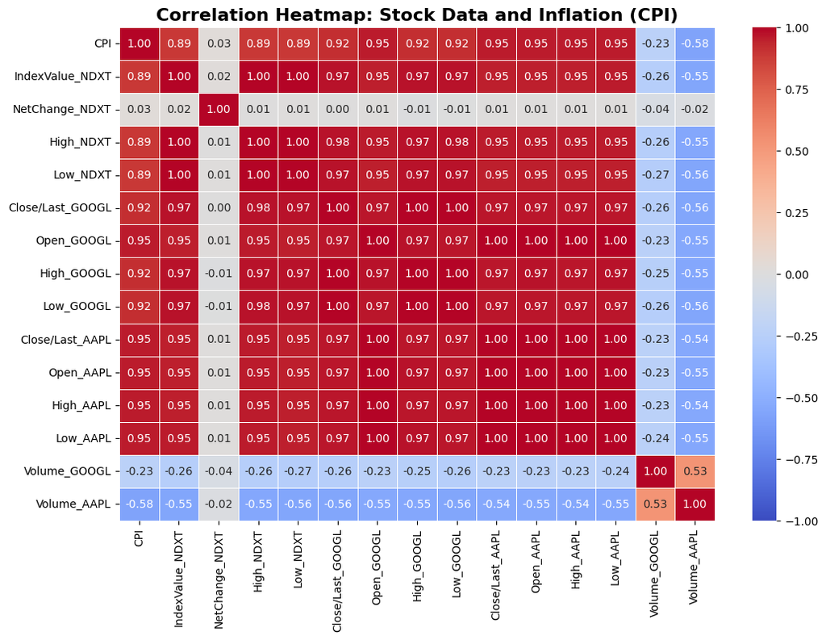

```python
# @title
import matplotlib.pyplot as plt
import seaborn as sns
columns_to_analyze = [
    "CPI",
    "IndexValue_NDXT",
    "NetChange_NDXT",
    "High_NDXT",
    "Low_NDXT",
    "Close/Last_GOOGL",
    "Open_GOOGL",
    "High_GOOGL",
    "Low_GOOGL",
    "Close/Last_AAPL",
    "Open_AAPL",
    "High_AAPL",
    "Low_AAPL",
    "Volume_GOOGL",
    "Volume_AAPL"
]

correlation_data = final_data[columns_to_analyze]
corr_matrix = correlation_data.corr()
plt.figure(figsize=(12, 8))
sns.heatmap(corr_matrix, annot=True, fmt=".2f", vmin=-1.0, vmax=1.0, cmap="coolwarm", linewidths=0.5)

plt.title("Correlation Heatmap: Stock Data and Inflation (CPI)", fontsize=16, fontweight='bold')

plt.show()
```

**Figure 1:** The correlation matrix of all included datasets, visualizing the correlation coefficients between various financial indicators, including Consumer Price Index (CPI), stock prices (GOOGL & AAPL), NASDAQ Tech Index (NDXT), and trading volumes. CPI shows a strong positive correlation with GOOGL and AAPL stock prices (above 0.90), suggesting that inflation and stock prices tend to move together. NASDAQ Tech Index (NDXT) also correlates highly with stock prices, implying that tech stocks follow overall market trends. Trading volumes (GOOGL & AAPL) exhibit negative correlations with stock prices, indicating that higher trading volumes may coincide with stock price declines.

# **Methodology**

The methodology is split into three stages:

1. Stage 1 involves fitting an ARIMA model -- outlined in the $y(t)$ equation below -- to every dataset and then taking the residual between the data and the fit. The ARIMA hyperparameters for each dataset are obtained using a stationarity test for *i* and the Akaike Information Criterion (AIC) for *p* and *q*, with the AIC equation shown below. The residual between the data and the ARIMA fit, also shown in an equation below, is calculated for input into Stage 2.

$y(t) = \mu + \epsilon_t + \sum^{P}_{p=1}a_i y(t-p) + \sum^{Q}_{q=1}\theta_q \epsilon_{q-1} + \sum^{D}_{d} dX_{t-1} - X_{t-d}$

$AIC = -\frac{2}{N}log(L) + \frac{2}{N}k$

$residual = y_{data} - y_{ARIMA \, Fit}$

2. Stage 2 introduces the LSTM portion of the hybrid model. By training an LSTM on the residuals from the ARIMA model, we hope it learns the unpredictable or nonlinear aspects of the data that ARIMA misses.
3. Stage 3 combines the determined ARIMA hyperparameters and trained LSTM model to forecast into the future. Both the ARIMA model and LSTM model for the residual are forecasted into the future. Added the results of these two forecasts together results in the combined forecast from both models. For our work, we forecast 80 days into the future due to the sampling rate of our data.

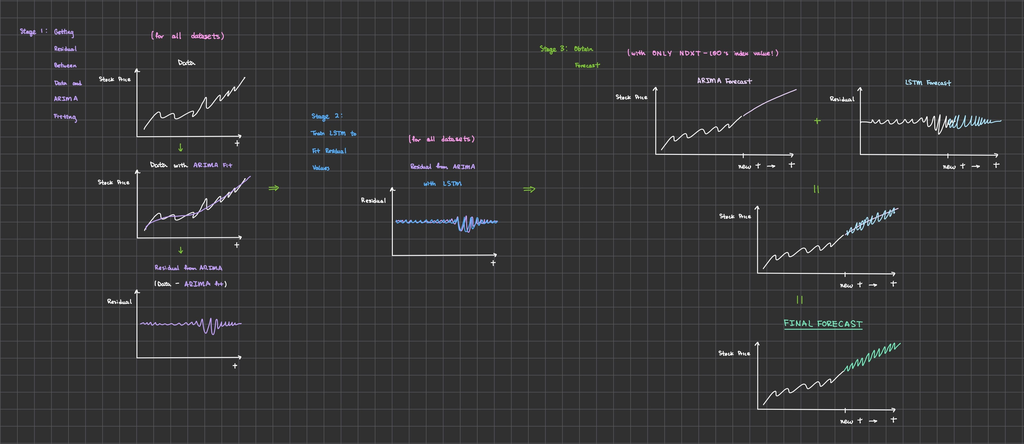

**Figure 2**: A hand-drawn diagram roughly outlining the methodology process taken.

## **Finding the Residuals of the Datasets from an ARIMA Fit Using AIC Criterion**

To demonstrate the method which was used to perform the ARIMA fitting for each time series, the process will be shown for a single time series, the high price of Apple stock.

```python
# @title
# import needed packages (that were not imported in previous code)
import statsmodels.api as sm

# read in the data set (with data points every four days)
data = pd.read_csv('https://raw.githubusercontent.com/jclauss24/MTLSA_Project/refs/heads/main/Data/processed_data_4day.csv')

# set the significance threshold for the test being performed
significance_threshold = 0.05

print ("Stationarity results from the AD Fuller test at a p-value of 0.05")

unittest = sm.tsa.stattools.adfuller(data['High_AAPL'])
print('High_AAPL', unittest) # use the ADfuller test that we tried in class - that notebook is here  https://github.com/fedhere/MLTSA_FBianco/blob/main/CodeExamples/ARMA/testingARMA_ARIMA.ipynb
print(f"statistics value: {unittest[0]}")
print(f"p-value: {unittest[1]}")
print(f"is p-value < {significance_threshold}? {unittest[1]<significance_threshold}")
print(f"\nis there a unit test? {unittest[1]>=significance_threshold}")
print(f"\nis it stationary? {unittest[1]<significance_threshold}")

if unittest[1]<significance_threshold:
  stationary=1
else:
  stationary=0
```

```
Stationarity results from the AD Fuller test at a p-value of 0.05
High_AAPL (np.float64(-0.05897901157768281), np.float64(0.9533741786200064), 1, 911, {'1%': np.float64(-3.437548486956221), '5%': np.float64(-2.864717822047763), '10%': np.float64(-2.5684620784026433)}, np.float64(4232.98429724922))
statistics value: -0.05897901157768281
p-value: 0.9533741786200064
is p-value < 0.05? False

is there a unit test? True

is it stationary? False
```

The next step in the process of completing the ARIMA fitting is to find the values of the hyperparameters $p$ and $q$ using the AIC criterion. The best values for these hyperparameters for the High value of Apple stock is shown in the following block of code.

It should be noted that within the full code for this project the value of $p$ was allowed to vary between $0$ and $20$ and the value of $q$ was allowed to vary between $0$ and $10$. Here the possible values of $p$ and $q$ are restricted further to reduce the time required to find the best values for demonstration purposes.

```python
# @title
import warnings

def getPandQ(dataColumn):
  i = stationary
  aics = np.zeros((6,6))
  for p in range(6):
      for q in range(6):
        try:
            mod = sm.tsa.ARIMA(dataColumn, order=(p,i,q))
            mod = mod.fit()
            #print(mod)
            aics[p][q] = mod.aic

        except:
            aics[p][q] = np.nan

  p,q = np.where(aics == np.nanmin(aics))
  print(f"p: {p[0]}")
  print(f"q: {q[0]}")
  return p[0], q[0]

with warnings.catch_warnings():
  warnings.simplefilter("ignore")
  p, q = getPandQ(data['High_AAPL'])
```

```
p: 3
q: 5
```

Once the best hyperparameters were found using the AIC criterion, the ARIMA fit itself could be found using those hyperparameters. The fitting is completed by using the method provided in the stats models time series package in Python.

The residuals are also then obtained by subtracting the ARIMA fit from the actual data.

Both the fitting of the ARIMA model and the calculation of the residuals are shown in the following block of code.

```python
# @title
# we are evaluating the high value of apple stock
column_name = 'High_AAPL'

# create the ARIMA model with the best found hyper parameters
arima_model = sm.tsa.ARIMA(data[column_name], order=(p, stationary, q))
# fit the model to the data
model_fit = arima_model.fit()

# find the ARIMA prediction of the data
prediction = model_fit.predict(start = 1, end=len(data[column_name]))
# calculate the residual from the ARIMA fit
residual = data[column_name] - prediction
```

We will now plot both the ARIMA fit and the residuals to show one example of the general structure of the fits and residuals.

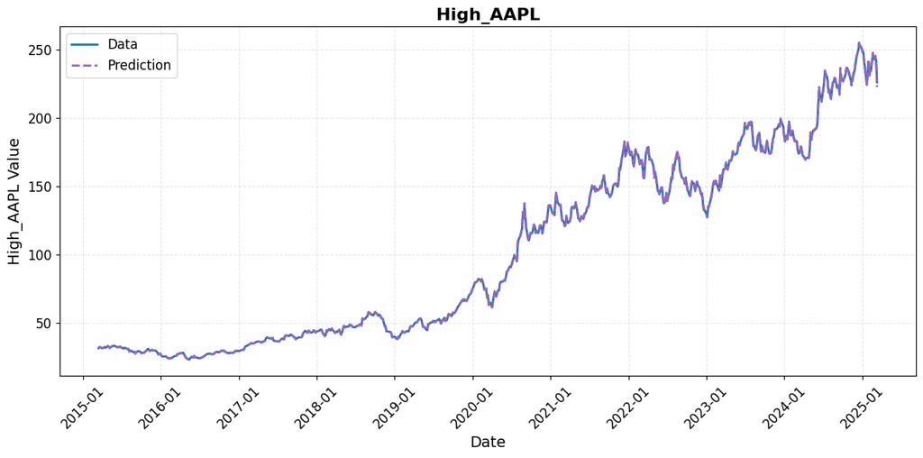

```python
# @title
import matplotlib.pyplot as plt
import matplotlib.dates as mdates

# plot the ARIMA fit and the original data
plt.figure(figsize=(12, 6))

# Plot actual data
plt.plot(pd.to_datetime(data['Date']), data[column_name], label='Data', linewidth=2, color='tab:blue')

# Plot prediction
plt.plot(pd.to_datetime(data['Date']), prediction, linestyle='--', color='tab:purple', label='Prediction', linewidth=2)

# Title and labels
plt.title(column_name, fontsize=16, fontweight='bold')
plt.xlabel('Date', fontsize=14)
plt.ylabel(column_name + " Value", fontsize=14)

# Styling
plt.legend(loc='upper left', fontsize=12)
plt.grid(True, linestyle='--', alpha=0.3)
plt.xticks(fontsize=12, rotation=45)
plt.yticks(fontsize=12)

# Format date ticks
ax = plt.gca()
ax.xaxis.set_major_locator(mdates.AutoDateLocator())
ax.xaxis.set_major_formatter(mdates.DateFormatter('%Y-%m'))

plt.tight_layout()
plt.show()
```

**Figure 3:** The ARIMA fit of the high value of Apple stock over time. The ground truth of the data is shown as a solid blue line. The ARIMA fit of the data is shown as a dashed purple line.

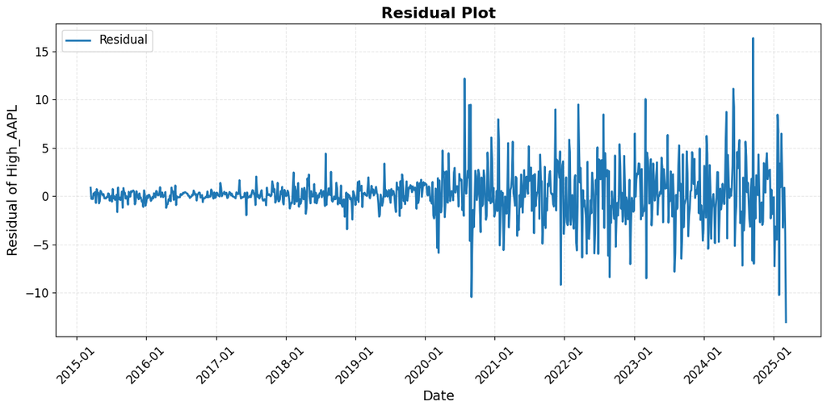

```python
# @title
import matplotlib.dates as mdates
import matplotlib.pyplot as plt

plt.figure(figsize=(12, 6))

# Plot residuals
plt.plot(pd.to_datetime(data['Date']), residual[1:], label='Residual', linewidth=2, color='tab:blue')

# Title and labels
plt.title('Residual Plot', fontsize=16, fontweight='bold')
plt.xlabel('Date', fontsize=14)
plt.ylabel('Residual of ' + column_name, fontsize=14)

# Styling
plt.legend(loc='upper left', fontsize=12)
plt.grid(True, linestyle='--', alpha=0.3)
plt.xticks(fontsize=12, rotation=45)
plt.yticks(fontsize=12)

# Format date ticks
ax = plt.gca()
ax.xaxis.set_major_locator(mdates.AutoDateLocator())
ax.xaxis.set_major_formatter(mdates.DateFormatter('%Y-%m'))

plt.tight_layout()
plt.show()
```

**Figure 4:** The ARIMA fit completed on the data for the high value of Apple stocks. The value of the residual is shown as a blue line. The residuals can be seen to get much larger near the year 2020. This occurs because at this time the data itself becomes much more noisy. It can also be seen that the residuals do not have any structure, and are instead purely noise.

Additional exploration of the residual behavior (i.e. percentage residual, power series of residuals), as alluded to in the caption of Figure 4, can be found in [this notebook](https://github.com/jclauss24/MTLSA_Project/blob/main/Analysis/arima_residual_exploration.ipynb) on our project GitHub repo.

## **Using ARIMA to Generate Predictions of NDXT-100 behavior**

The final step in our analysis utilizing ARIMA is to complete the ARIMA prediction. A prediction of the final 80 days in the dataset is completed using ARIMA on the value of the NDXT-100 as a forecast 80 days into the future is desired. The hyperparameters used for this prediction are found using the AIC criterion similarly to those shown above.

[figure not shown]

```python
# @title
# predict the value of NDXT-100
column_name = "IndexValue_NDXT"
#predict the last 80 days of the data set (since it is sampled every four days this is 20 data points)
N_test = 20
# the best hyperparameters for the ARIMA model found using the AIC Criterion
p = 5
i = 0
q = 5

#create the ARIMA model
arma_model = sm.tsa.ARIMA(data.iloc[:-N_test][column_name], order=(p, i, q))
model_fit = arma_model.fit()

# generate the ARIMA prediction and the confidence interval
prediction = model_fit.get_forecast(N_test)
yhat = prediction.predicted_mean
yhat_conf_int = prediction.conf_int(alpha=0.05)

#create an array of the date values for the data as an array of datetime values
tVals = data.loc[1:, "Date"]
tVals.reset_index(drop=True, inplace=True)
tVals = pd.to_datetime(tVals)

# plot the ground truth (the actual value of the NDXT-100)
import matplotlib.dates as mdates
import matplotlib.pyplot as plt

plt.figure(figsize=(12, 6))

# Plot ground truth
plt.plot(tVals[:-N_test], data.iloc[:-N_test-1][column_name], label='Ground Truth', linewidth=2, color='tab:blue')

# Plot predicted values
plt.plot(tVals[-N_test:], yhat, label="Predicted", color="orange", linewidth=2)

# Confidence interval
plt.fill_between(tVals[-N_test:],
                 yhat_conf_int["lower " + column_name],
                 yhat_conf_int["upper " + column_name],
                 color='orange', alpha=0.3, label='95% Confidence Interval')


# Title and labels
plt.title("Prediction of the Last 80 days (20 Steps) with Uncertainty", fontsize=16, fontweight='bold')
plt.xlabel("Date", fontsize=14)
plt.ylabel("NDXT Value", fontsize=14)

# Styling
plt.legend(loc='upper left', fontsize=12)
plt.grid(True, linestyle='--', alpha=0.3)
plt.xticks(fontsize=12, rotation=45)
plt.yticks(fontsize=12)

# Format date ticks
ax = plt.gca()
ax.xaxis.set_major_locator(mdates.AutoDateLocator())
ax.xaxis.set_major_formatter(mdates.DateFormatter('%Y-%m'))

plt.tight_layout()
plt.show()
```

**Figure 5:** The ARIMA prediction of the value of the NDXT-100. The ground truth of the data up until the time of the start of the prediction is shown in dark blue. The mean value of the prediction is shown as an orange line, and the confidence interval of the prediction is shown as a light orange shaded region.

This ARIMA prediction of the behavior is saved as CSV file that can be accessed on Github through [this link](https://github.com/jclauss24/MTLSA_Project/blob/main/Data/predicted_data.csv).

## **Using LSTM to model the residual behavior**

A Long Short Term Memory (LSTM) Neural Network was then used to predict the residuals of the ARIMA fit. The LSTM was trained on all of the residuals generated from ARIMA fits using the AIC criterion.

The dataset was loaded from a CSV file containing residual index values. Missing entries are removed along with an extraneous index column (`Unnamed: 0`). Standardization was performed before any neural network analysis; this was performed using `StandardScaler` from `sklearn`, ensuring that each feature had zero mean and unit variance.

Necessary Python libraries are imported first below.

```python
# @title
import pandas as pd
import numpy as np
import pylab as pl
import glob
%pylab inline
import statsmodels.api as sm
from pandas.plotting import scatter_matrix
import json
import os
from sklearn.metrics import mean_squared_error
```

```python
# @title
from keras.models import Sequential
from keras.layers import LSTM, Dense, TimeDistributed
from keras.callbacks import EarlyStopping, ModelCheckpoint
import numpy as np
import pandas as pd
import matplotlib.pyplot as plt
from tqdm import tqdm
from sklearn.preprocessing import StandardScaler
from sklearn.model_selection import train_test_split
```

```python
# @title
data = pd.read_csv("https://raw.githubusercontent.com/jclauss24/MTLSA_Project/refs/heads/main/Data/selectResidualsFinal_4day_good.csv")
df_clean = data.dropna()
for i in data.columns:
    nan_count_column = df_clean[i].isna().sum()
    print("NaN count in column:", nan_count_column)
df_clean = df_clean.drop('Unnamed: 0', axis=1)
df_clean.head()
tVals = np.arange(0, 912, 1)
```

```
NaN count in column: 0
NaN count in column: 0
NaN count in column: 0
NaN count in column: 0
NaN count in column: 0
NaN count in column: 0
NaN count in column: 0
NaN count in column: 0
NaN count in column: 0
NaN count in column: 0
NaN count in column: 0
NaN count in column: 0
NaN count in column: 0
NaN count in column: 0
NaN count in column: 0
NaN count in column: 0
```

```python
# @title
scaler = StandardScaler()
data_t = df_clean.transpose()
scaled_data_t = scaler.fit_transform(df_clean)
scaled_data = scaled_data_t.transpose()

print(scaler.mean_)
```

```
[ 7.87627022e+00 -3.98516555e+05 -1.12227785e+06  3.06999288e-03
  1.31137607e-01  1.62954529e-01  2.19977101e+00  6.68795157e+00
  7.38898561e+00  1.38659276e-01  1.62583088e-01  1.39073195e-01
  1.62954529e-01  1.62583088e-01  1.45842184e-01]
```

```python
# @title
scaled_data.mean(axis=1)
scaled_data.std(axis=1)
scaled_data = scaled_data.transpose()
scaled_data.shape
```

```
(912, 15)
```

```python
# @title
split_index = int(len(scaled_data) * 0.8)
training_set = scaled_data[:split_index]
test_set = scaled_data[split_index:]
```

To train the model, the scaled time series data was split into **80%** training and **20%** testing. This approach ensures temporal continuity, a crucial factor in time series modeling, avoiding information leakage from future data into the past.

```python
# @title
split_index = int(len(scaled_data) * 0.8)
training_set = scaled_data[:split_index]
test_set = scaled_data[split_index:]
```

As the next step, wi'll reshaping the data into sequences of time steps, where the model learns to predict future values based on a window of past values. Each input sequence (X) consists of 100 previous time steps, and each target output (y) is the next value in the sequence. This effectively structures the input for a sequence-to-vector prediction task, where the network uses past time steps to predict the next feature vector.

```python
# @title
def create_dataset(data, look_back=100):
    X, y = [], []
    for i in range(len(data) - look_back):
        X.append(data[i:i + look_back, :])
        y.append(data[i + look_back, :])
    return np.array(X), np.array(y)

X_train, y_train = create_dataset(training_set, look_back=100)
X_test, y_test = create_dataset(test_set, look_back=100)
```

The LSTM model was built using the Keras Sequential API with the following architecture:

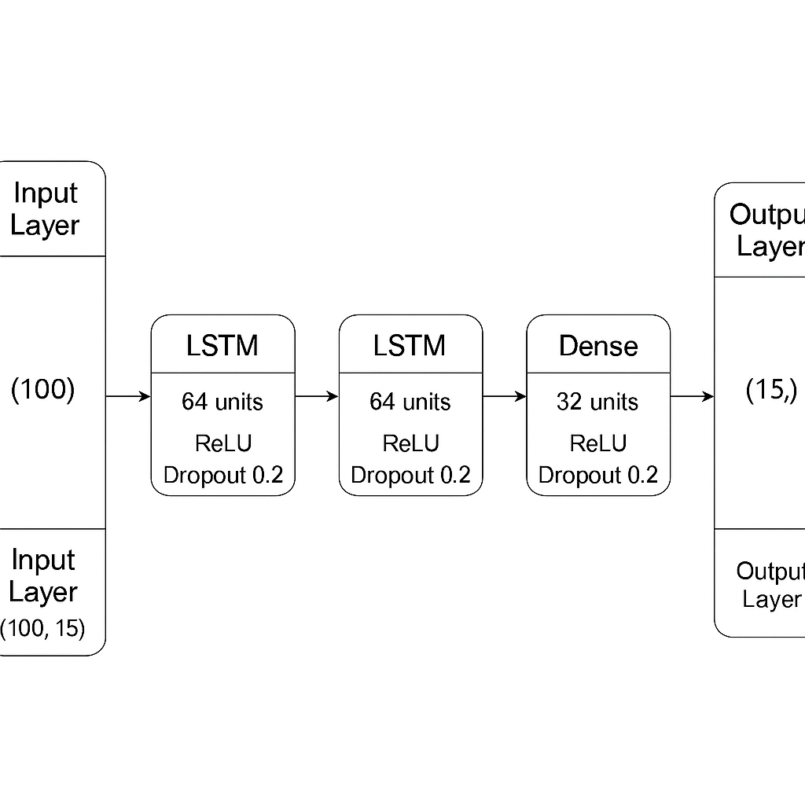

**Figure 6:** Schematic of the LSTM neural network architecture. It consists of an input layer, two 64-neuron LSTM layers, a 32-neuron dense layer, and an output layer.

```python
# @title
from keras import layers
def create_lstm_model(input_shape):
    model = Sequential([
        # Input layer, shape 100 * 15
        layers.InputLayer(input_shape=input_shape),

        # LSTM layer 1
        layers.LSTM(units=64, return_sequences=True, activation='relu'),  # Increased units
        layers.Dropout(0.2),

        # LSTM layer 2
        layers.LSTM(units=64, return_sequences=False, activation='relu'), # Added another LSTM layer
        layers.Dropout(0.2),

        # Dense layer 1
        layers.Dense(units=32, activation='relu'), # Added a Dense Layer
        layers.Dropout(0.2),

        # Output layer
        layers.Dense(units=15)  # Predict the next 15 time steps
    ])
    return model
def prepare_data(data, n_steps_in, n_steps_out):
    """
    Prepares the data for the LSTM model.

    Args:
        data (np.ndarray): The time series data.
        n_steps_in (int): The number of time steps to look back.
        n_steps_out (int): The number of time steps to predict.

    Returns:
        tuple: A tuple containing X and y, the input and output sequences.
    """
    X, y = [], []
    for i in range(len(data) - n_steps_in - n_steps_out + 1):
        seq_x = data[i:i + n_steps_in]
        seq_y = data[i + n_steps_in:i + n_steps_in + n_steps_out]
        X.append(seq_x)
        y.append(seq_y)
    return np.array(X), np.array(y)
input_shape = (10, 15)
model = create_lstm_model(input_shape)

model.summary()

es = EarlyStopping(monitor='val_loss', mode='min', verbose=1, patience=10)
# mc = ModelCheckpoint('best_model.h5', monitor='val_loss', mode='min', verbose=1, save_best_only=True)
mc = ModelCheckpoint('best_model.keras', monitor='val_loss', mode='min', verbose=1, save_best_only=True)

split_index = int(len(scaled_data) * 0.8)
training_set = scaled_data[:split_index]
test_set = scaled_data[split_index:]

# X_train, y_train = training_set, training_set
# X_test, y_test = test_set, test_set
X_train, y_train = create_dataset(training_set, look_back=100)
X_test, y_test = create_dataset(test_set, look_back=100)
```

```
Model: "sequential"
```

```
┏━━━━━━━━━━━━━━━━━━━━━━━━━━━━━━━━━┳━━━━━━━━━━━━━━━━━━━━━━━━┳━━━━━━━━━━━━━━━┓
┃ Layer (type)                    ┃ Output Shape           ┃       Param # ┃
┡━━━━━━━━━━━━━━━━━━━━━━━━━━━━━━━━━╇━━━━━━━━━━━━━━━━━━━━━━━━╇━━━━━━━━━━━━━━━┩
│ lstm (LSTM)                     │ (None, 10, 64)         │        20,480 │
├─────────────────────────────────┼────────────────────────┼───────────────┤
│ dropout (Dropout)               │ (None, 10, 64)         │             0 │
├─────────────────────────────────┼────────────────────────┼───────────────┤
│ lstm_1 (LSTM)                   │ (None, 64)             │        33,024 │
├─────────────────────────────────┼────────────────────────┼───────────────┤
│ dropout_1 (Dropout)             │ (None, 64)             │             0 │
├─────────────────────────────────┼────────────────────────┼───────────────┤
│ dense (Dense)                   │ (None, 32)             │         2,080 │
├─────────────────────────────────┼────────────────────────┼───────────────┤
│ dropout_2 (Dropout)             │ (None, 32)             │             0 │
├─────────────────────────────────┼────────────────────────┼───────────────┤
│ dense_1 (Dense)                 │ (None, 15)             │           495 │
└─────────────────────────────────┴────────────────────────┴───────────────┘
```

```
 Total params: 56,079 (219.06 KB)
```

```
 Trainable params: 56,079 (219.06 KB)
```

```
 Non-trainable params: 0 (0.00 B)
```

The model was compiled with the **Adam** optimizer and **Mean Squared Error (MSE)** as the loss function.

```python
# @title
model.compile(optimizer='adam', loss='mean_squared_error')
```

```python
# @title
training = model.fit(x=X_train, y=y_train,
                     validation_split=0.1, epochs=50, batch_size=10, verbose=1, callbacks=[mc])
```

```
57/57 ━━━━━━━━━━━━━━━━━━━━ 0s 77ms/step - loss: 0.6526
Epoch 1: val_loss improved from inf to 1.71273, saving model to best_model.keras
57/57 ━━━━━━━━━━━━━━━━━━━━ 11s 100ms/step - loss: 0.6547 - val_loss: 1.7127
57/57 ━━━━━━━━━━━━━━━━━━━━ 0s 78ms/step - loss: 0.8575
Epoch 2: val_loss improved from 1.71273 to 1.71087, saving model to best_model.keras
57/57 ━━━━━━━━━━━━━━━━━━━━ 5s 83ms/step - loss: 0.8560 - val_loss: 1.7109
57/57 ━━━━━━━━━━━━━━━━━━━━ 0s 69ms/step - loss: 0.7897
Epoch 3: val_loss improved from 1.71087 to 1.70993, saving model to best_model.keras
57/57 ━━━━━━━━━━━━━━━━━━━━ 5s 73ms/step - loss: 0.7894 - val_loss: 1.7099
57/57 ━━━━━━━━━━━━━━━━━━━━ 0s 92ms/step - loss: 0.6839
Epoch 4: val_loss did not improve from 1.70993
57/57 ━━━━━━━━━━━━━━━━━━━━ 5s 95ms/step - loss: 0.6854 - val_loss: 1.7104
57/57 ━━━━━━━━━━━━━━━━━━━━ 0s 69ms/step - loss: 0.7143
Epoch 5: val_loss did not improve from 1.70993
57/57 ━━━━━━━━━━━━━━━━━━━━ 9s 73ms/step - loss: 0.7152 - val_loss: 1.7112
57/57 ━━━━━━━━━━━━━━━━━━━━ 0s 80ms/step - loss: 0.7539
Epoch 6: val_loss did not improve from 1.70993
57/57 ━━━━━━━━━━━━━━━━━━━━ 6s 84ms/step - loss: 0.7541 - val_loss: 1.7110
57/57 ━━━━━━━━━━━━━━━━━━━━ 0s 65ms/step - loss: 0.6815
Epoch 7: val_loss did not improve from 1.70993
57/57 ━━━━━━━━━━━━━━━━━━━━ 4s 69ms/step - loss: 0.6830 - val_loss: 1.7150
57/57 ━━━━━━━━━━━━━━━━━━━━ 0s 83ms/step - loss: 0.7647
Epoch 8: val_loss did not improve from 1.70993
57/57 ━━━━━━━━━━━━━━━━━━━━ 5s 89ms/step - loss: 0.7647 - val_loss: 1.7205
57/57 ━━━━━━━━━━━━━━━━━━━━ 0s 72ms/step - loss: 0.7382
Epoch 9: val_loss did not improve from 1.70993
57/57 ━━━━━━━━━━━━━━━━━━━━ 4s 76ms/step - loss: 0.7386 - val_loss: 1.7269
57/57 ━━━━━━━━━━━━━━━━━━━━ 0s 68ms/step - loss: 0.8052
Epoch 10: val_loss did not improve from 1.70993
57/57 ━━━━━━━━━━━━━━━━━━━━ 5s 72ms/step - loss: 0.8043 - val_loss: 1.7187
57/57 ━━━━━━━━━━━━━━━━━━━━ 0s 88ms/step - loss: 0.7818
Epoch 11: val_loss did not improve from 1.70993
57/57 ━━━━━━━━━━━━━━━━━━━━ 6s 91ms/step - loss: 0.7814 - val_loss: 1.7160
57/57 ━━━━━━━━━━━━━━━━━━━━ 0s 70ms/step - loss: 0.6790
Epoch 12: val_loss did not improve from 1.70993
57/57 ━━━━━━━━━━━━━━━━━━━━ 4s 73ms/step - loss: 0.6803 - val_loss: 1.7258
57/57 ━━━━━━━━━━━━━━━━━━━━ 0s 75ms/step - loss: 0.7255
Epoch 13: val_loss did not improve from 1.70993
57/57 ━━━━━━━━━━━━━━━━━━━━ 6s 82ms/step - loss: 0.7259 - val_loss: 1.7774
57/57 ━━━━━━━━━━━━━━━━━━━━ 0s 73ms/step - loss: 0.7669
```

[output cut: 95 more lines]

```
57/57 ━━━━━━━━━━━━━━━━━━━━ 0s 74ms/step - loss: 0.5807
Epoch 46: val_loss did not improve from 1.69949
57/57 ━━━━━━━━━━━━━━━━━━━━ 4s 77ms/step - loss: 0.5801 - val_loss: 2.8719
57/57 ━━━━━━━━━━━━━━━━━━━━ 0s 92ms/step - loss: 0.5384
Epoch 47: val_loss did not improve from 1.69949
57/57 ━━━━━━━━━━━━━━━━━━━━ 6s 98ms/step - loss: 0.5382 - val_loss: 2.7906
57/57 ━━━━━━━━━━━━━━━━━━━━ 0s 71ms/step - loss: 0.5289
Epoch 48: val_loss did not improve from 1.69949
57/57 ━━━━━━━━━━━━━━━━━━━━ 9s 75ms/step - loss: 0.5292 - val_loss: 2.6495
57/57 ━━━━━━━━━━━━━━━━━━━━ 0s 83ms/step - loss: 0.5916
Epoch 49: val_loss did not improve from 1.69949
57/57 ━━━━━━━━━━━━━━━━━━━━ 6s 86ms/step - loss: 0.5905 - val_loss: 2.4985
57/57 ━━━━━━━━━━━━━━━━━━━━ 0s 69ms/step - loss: 0.5360
Epoch 50: val_loss did not improve from 1.69949
57/57 ━━━━━━━━━━━━━━━━━━━━ 4s 73ms/step - loss: 0.5361 - val_loss: 2.8401
```

# **Results**

## **Model Loss Behavior**

The results of training the LSTM model with the details above is shown in Figure 7 below. The training loss shows a downward trend, indicating learning, while the validation shows an upward trend, indicating the lack of learning done by the neural network. Considering that the residual data is essentially random noise, this is not unexpected validation loss behavior.

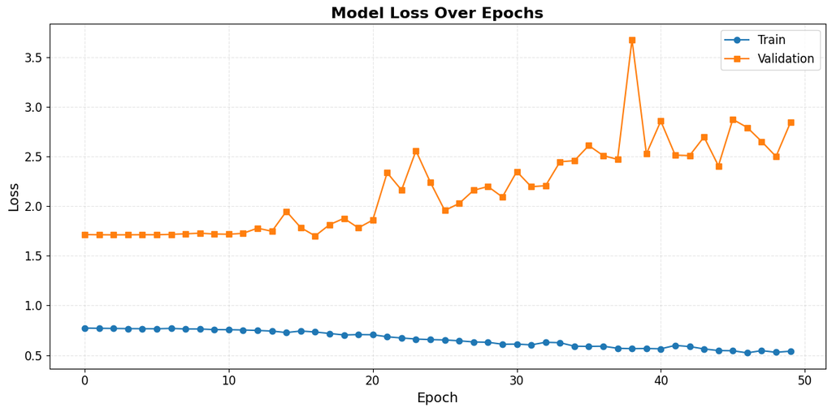

```python
# @title
plt.figure(figsize=(12, 6))
plt.plot(training.history['loss'], label='Train', linewidth=1.5, marker='o')
plt.plot(training.history['val_loss'], label='Validation', linewidth=1.5, marker='s')
plt.title('Model Loss Over Epochs', fontsize=16, fontweight='bold')
plt.xlabel('Epoch', fontsize=14)
plt.ylabel('Loss', fontsize=14)
plt.legend(loc='upper right', fontsize=12)
plt.grid(True, linestyle='--', alpha=0.3)
plt.xticks(fontsize=12)
plt.yticks(fontsize=12)
plt.tight_layout()
plt.show()
```

**Figure 7:** Loss vs. Epoch for the tranining of the LSTM neural network. The training loss is shown in blue, while the validation is shown in orange.

## **LSTM + ARIMA and ARIMA-only Prediction and Forecast**

Since a forecast 80 days into the future is desired, a prediction for the residual for the last 80 days in the dataset is made. The model uses the final 10 known time steps (before the withheld period) to initiate predictions.

```python
# @title
look_back = 10
scaled_data_new = scaled_data[:-20]
last_sequence = scaled_data_new[-look_back:]
input_seq = last_sequence.reshape(1, look_back, 15)
```

For each of the next 20 time steps (equivalent to 80 days of market data sampled every four days), the LSTM generates a prediction. The predicted value is then appended to the sequence to forecast subsequent steps.

```python
# @title
future_predictions = []

for _ in range(20):
    next_pred = model.predict(input_seq, verbose=0)[0, -1]
    future_predictions.append(next_pred)
    next_pred_reshaped = np.repeat(next_pred, 15).reshape(1, 1, 15)
    input_seq = np.concatenate((input_seq[:, 1:, :], next_pred_reshaped), axis=1)
```

Since the model operates on normalized data, predictions are transformed back to their original scale.

```python
# @title
future_predictions_full = np.zeros((len(future_predictions), 15))
future_predictions_full[:, 0] = future_predictions
future_predictions_scaled = scaler.inverse_transform(future_predictions_full)
future_predictions_original = future_predictions_scaled[:, 0]
```

```python
# @title
dataActualNotResidual = pd.read_csv("https://raw.githubusercontent.com/jclauss24/MTLSA_Project/refs/heads/main/Data/processed_data_4day.csv")

# Ensure date format for x-axis
date_rng = dataActualNotResidual['Date'][-20:]
tValuesPredict = date_rng
tValuesPredict = pd.to_datetime(tValuesPredict)

import matplotlib.pyplot as plt
import matplotlib.dates as mdates
tValues = dataActualNotResidual['Date'][1:]
tValuesPredict = pd.to_datetime(tValuesPredict)
tValues = pd.to_datetime(tValues)
```

This residual prediction from the LSTM model is then added to the ARIMA prediction from Figure 5, as shown in Figure 8 below.

[figure not shown]

```python
# @title
import matplotlib.pyplot as plt
dataPredictedARIMA = pd.read_csv("https://raw.githubusercontent.com/jclauss24/MTLSA_Project/refs/heads/main/Data/predicted_data.csv")
Last20Pred = dataPredictedARIMA['last_20_pred'][-20:]
TotalPred_ARIMA_LSTM = Last20Pred + future_predictions_original


# tValues = np.arange(0, 912, 1)
tValues = dataActualNotResidual['Date'][1:-20]
tValues = pd.to_datetime(tValues)
# tValuesPredict = np.arange(912, 912 + len(future_predictions_original), 1)
date_rng = dataActualNotResidual['Date'][-20:]
tValuesPredict = date_rng
tValuesPredict = pd.to_datetime(tValuesPredict)

start = tValuesPredict.values[0]
end = tValuesPredict.values[-1]

plt.figure(figsize=(12, 6))

plt.plot(tValues, dataActualNotResidual['IndexValue_NDXT'][1:-20],
         label='Index Value of NDXT (Historical)', color="tab:blue", linewidth=2)

plt.plot(tValuesPredict, dataActualNotResidual['IndexValue_NDXT'][-20:],
         label='True Future Values', color="tab:blue", alpha=0.4, linewidth=2)

plt.plot(tValuesPredict, TotalPred_ARIMA_LSTM,
         label='Predicted (ARIMA + LSTM)', color='green', linewidth=2)

# Add shaded area using safe values
plt.axvspan(start, end, color='orange', alpha=0.3, label='Prediction Horizon')

# Format date axis if datetime
if hasattr(start, 'strftime'):
    plt.gca().xaxis.set_major_formatter(mdates.DateFormatter('%Y-%m-%d'))
    plt.gca().xaxis.set_major_locator(mdates.AutoDateLocator())
    plt.xticks(rotation=45)

plt.title("Index Value of NDXT with 80-Day Prediction", fontsize=16, fontweight='bold')
plt.xlabel("Date", fontsize=14)
plt.ylabel("Index Value", fontsize=14)
plt.legend(loc='upper left', fontsize=12)
plt.grid(True, linestyle='--', alpha=0.3)
plt.xticks(fontsize=12, rotation=45)
plt.yticks(fontsize=12)
plt.tight_layout()
plt.show()
```

The mean-square errors for the ARIMA+LSTM hybrid model and the ARIMA only model are $2.07\cdot10^5$ and $2.03\cdot10^5$ respectively, for the 80 day prediction. Since the residual acts as random noise, it may cause the ARIMA moving average to deviate from said average more compared to the data, giving a worse MSE value. This shows that the hybrid model performs slightly worse than an ARIMA only model for this test case, and does not provide significant improvement upon the ARIMA only model shown in Figure 5.

A forecast of the moving average with ARIMA is shown in Figure 9 below. The stock price is forecasted to rise slowly 80 days into the future.

[figure not shown]

```python
# @title
plt.figure(figsize=(12, 6))
plt.plot(date_rng[:-N_test], data[column_name], label='Ground Truth')
date_rng = pd.date_range(start=data['Date'].min(), end=('2025-05-31'), freq='4D')

# Plot the predictions with uncertainty
plt.plot(date_rng[-N_test:], yhat_15, label="Predicted", color="orange")
plt.fill_between(date_rng[-N_test:],  yhat_conf_int_15["lower " + column_name],
                 yhat_conf_int_15["upper " + column_name],
                 color="orange", alpha=0.3,
                 label="95% Confidence Interval")
plt.xlabel("Time", fontsize=14)
plt.ylabel("NDXT Value", fontsize=14)
plt.title("Forecast of 80 days into the Future with Uncertainty", fontsize=16, fontweight='bold')
plt.legend(fontsize=12)
plt.grid(True, linestyle='--', alpha=0.3)
plt.xticks(fontsize=12, rotation=45)
plt.yticks(fontsize=12)
plt.show()
```

The forecast of the residual using LSTM is shown below in Figure 10. Keeping in mind the behavior seen from the prediction, adding this forecasted residual to ARIMA forecast has negligible improvement compared to ARIMA-only forecast.

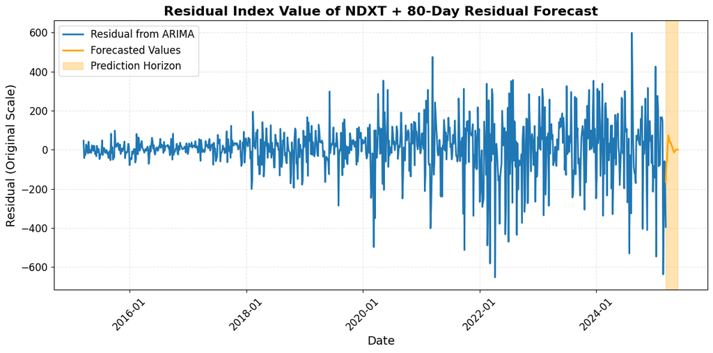

```python
# @title
tValues = pd.to_datetime(dataActualNotResidual['Date'][1:])
date_rng = pd.date_range(start=dataActualNotResidual['Date'].max(), end='2025-05-29', freq='4D')
tValuesPredict = pd.to_datetime(date_rng)

plt.figure(figsize=(12, 6))

# Plot historical residuals
plt.plot(tValues, df_clean['# IndexValue_NDXT'], label='Residual from ARIMA', linewidth=2, color='tab:blue')

# Plot forecasted values
plt.plot(tValuesPredict, future_predictions_original, label='Forecasted Values', color='orange', linewidth=2)

# Prediction region highlight
plt.axvspan(tValuesPredict[0], tValuesPredict[-1], color='orange', alpha=0.3, label='Prediction Horizon')

# Title and labels
plt.title("Residual Index Value of NDXT + 80-Day Residual Forecast", fontsize=16, fontweight='bold')
plt.xlabel("Date", fontsize=14)
plt.ylabel("Residual (Original Scale)", fontsize=14)

# Styling
plt.legend(loc='upper left', fontsize=12)
plt.grid(True, linestyle='--', alpha=0.3)
plt.xticks(fontsize=12, rotation=45)
plt.yticks(fontsize=12)

# Format date ticks
ax = plt.gca()
ax.xaxis.set_major_locator(mdates.AutoDateLocator())
ax.xaxis.set_major_formatter(mdates.DateFormatter('%Y-%m'))

plt.tight_layout()
plt.show()
```

# Conclusions and Future Work

Overall, the use of an LSTM model to predict the residuals of the ARIMA fits does not improve the prediction or forecasting of the behavior of the NDXT-100 value. The ARIMA fitting performed was able to fit the stock data very well, causing the residuals to be purely noise and not contain any sort of underlying structure. This meant that there was no structure for the LSTM to be able to learn from the data. Random noise cannot be predicted by any model, and so the use of an LSTM does not improve the accuracy of this model.

To improve the prediction and forecast, something has to change inherently about the approach to the problem. If the ARIMA residuals always look like noise, then using an LSTM neural network will not achieve anything. Though work can be done to make the ARIMA fit worse in hopes of obtaining structure in the residual data, the biggest area of change can be to include news headline data with sentiment analysis, which is one of the biggest influences on stock behavior. More varied stock data (i.e. materials index data that is used commonly in the technology sector, macroeconomic information, and incorporation of technical indicators (i.e. more quantitative analysis on historical price data before inputting data) can also be done to potentially improve on this project.

# Link to GitHub Repo

The GitHub repository where this project was be developed can be found at: https://github.com/jclauss24/MTLSA_Project/tree/main.

# Bibliography

[1] Badolia, Lokesh. How can i get started investing in the stock market. Educreation Publishing, 2016.

[2] Fineberg, Steve, Susanne Hupfer, Michael Steinhart, Sayantani Mazumder, and Prashant Raman. “2025 Technology Industry Outlook.” Deloitte Insights, April 21, 2025. https://www2.deloitte.com/us/en/insights/industry/technology/technology-media-telecom-outlooks/technology-industry-outlook.html.

[3] Kumbure, Mahinda Mailagaha, Christoph Lohrmann, Pasi Luukka, and Jari Porras. "Machine learning techniques and data for stock market forecasting: A literature review." Expert Systems with Applications 197 (2022): 116659.

[4] Mintarya, Latrisha N., Jeta NM Halim, Callista Angie, Said Achmad, and Aditya Kurniawan. "Machine learning approaches in stock market prediction: A systematic literature review." Procedia Computer Science 216 (2023): 96-102.

[5] Liu, Yang. "Novel volatility forecasting using deep learning–long short term memory recurrent neural networks." Expert Systems with Applications 132 (2019): 99-109.